# Week 11 - Non-Linear Regression

Jeff Shamp

2021-04-16

## KJ 7.2

Friedman (1991) introduced several benchmark data sets create by simulation. One of these simulations used the following nonlinear equation to create data:

y = 10 sin(πx1x2) + 20(x3 − 0.5)2 + 10x4 + 5x5 + N(0, σ2)

where the x values are random variables uniformly distributed between [0, 1] (there are also 5 other non-informative variables also created in the simulation). The package mlbench contains a function called mlbench.friedman1 that simulates these data:

Tune several models on these data.

Which models appear to give the best performance? Does MARS select the informative predictors (those named X1–X5)?

```r
library(AppliedPredictiveModeling)
library(mlbench)
library(caret)
library(dplyr)
```

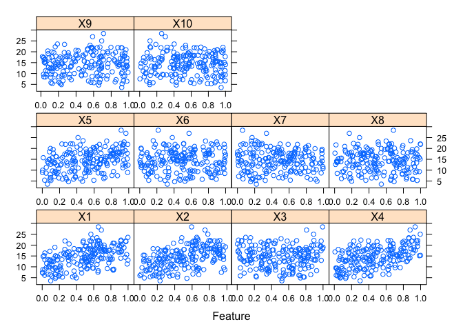

```r
set.seed(200)
training_data <- mlbench.friedman1(200, sd = 1)
training_data$x <- data.frame(training_data$x)
featurePlot(training_data$x, training_data$y)
```

```r
test_data <- mlbench.friedman1(5000, sd = 1)
test_data$x <- data.frame(test_data$x)
```

Look at this mess. There might be some associations here, but this pretty non-linear.

The book provides a benchmark KNN model with RMSE 3.22 and $R^{2} = 0.687$. Let’s try a few and see what works best.

### NN model

Way too many parameters go into this model especially the `MaxNWts`. We will preprocess to center and scale just so that all models have the same “ideal” workspace to fit.

```r
nn_tune <- expand.grid(.decay = c(0, 0.01, .1),
                        .size = c(1:10),
                        .bag = FALSE)

ctrl <- trainControl(method = "cv")

nn_model <- train(training_data$x,
                  training_data$y,
                  method = "avNNet",
                  tuneGrid = nn_tune,
                  trControl = ctrl,
                  preProcess = c("center", "scale"),
                  linout = TRUE,
                  trace = FALSE,
                  maxit = 500,
                  MaxNWts = 10 * (ncol(training_data$x) + 1) + 10 + 1)
```

```r
nn_predict <- predict(nn_model, newdata = test_data$x)
nn_results <- postResample(pred = nn_predict, obs = test_data$y)
nn_results
```

```
##      RMSE  Rsquared       MAE
## 2.5093746 0.7778381 1.8429557
```

### SVM RBF

I really like this model type, and it works well with many use cases I’ve come across.

```r
svm <- train(x=training_data$x,
             y=training_data$y,
             method="svmRadial",
             preProcess=c("center", "scale"),
             tuneLength=20)

svm_predict <- predict(svm, newdata=test_data$x)
svm_results<- postResample(pred=svm_predict, obs=test_data$y)
svm_results
```

```
##      RMSE  Rsquared       MAE
## 2.0825887 0.8242677 1.5822883
```

Better. Not amazingly better but this would be a better choice for it explanability and simplicity.

### MARS…ahem, earth

Apparently the use the term MARS model is copywritten or something like that, which is why the package calls it “earth”. Some people.

```r
mars_tune <- expand.grid(.degree=1:2, .nprune=2:38)

mars_model <- train(x=training_data$x,
                    y=training_data$y,
                    method="earth",
                    preProcess = c("center", "scale"),
                    tuneGrid=mars_tune,
                    trControl = ctrl)

mars_predict <- predict(mars_model, newdata=test_data$x)
mars_results <- postResample(pred=mars_predict, obs=test_data$y)
mars_results
```

```
##      RMSE  Rsquared       MAE
## 1.2793868 0.9343367 1.0091132
```

Mars/earth really nails the prediction for this data set.

### Feature Importance

Looks like the MARS model not only identified variable X1-X5 as important, but only gave importance to *those* variables and zeroed out the remaining.

```r
varImp(mars_model)
```

```
## earth variable importance
##
##     Overall
## X1   100.00
## X4    85.12
## X2    69.20
## X5    49.23
## X3    39.89
## X6     0.00
## X8     0.00
## X7     0.00
## X10    0.00
## X9     0.00
```

## KJ 7.5

Exercise 6.3 describes data for a chemical manufacturing process. Use the same data imputation, data splitting, and pre-processing steps as before and train several nonlinear regression models.

### Data Prep

I like these through lines in the HW. This dataset and the retail data from time series is nice to revisit.

First, all the data prep as the same from last week in one block. We will also train up several models and answer questions after all the models have been fit.

```r
data("ChemicalManufacturingProcess")
cmp <- as.data.frame(ChemicalManufacturingProcess)
x_raw <- cmp[,2:58]
y_raw <- as.matrix(cmp$Yield)

# impute via KNN
x_imp <- bnstruct::knn.impute(as.matrix(x_raw), k=10)
# Drop near zero variance
low_var <- nearZeroVar(x_imp)
x_lowvar <- x_imp[,-low_var]

# center, scale, Box Cox
x_trans <-  preProcess(x_lowvar, method=c('center', 'scale', 'BoxCox'))
x_trans <- predict(x_trans, x_lowvar)

# TTS
trainingRows <- createDataPartition(y_raw, p=0.8, list=FALSE)
train_X <- x_trans[trainingRows,]
train_y <- y_raw[trainingRows]

test_X <- x_trans[-trainingRows,]
test_y <- y_raw[-trainingRows]

trainingData <- as.data.frame(train_X)
trainingData$Yield <- train_y

#t_ctrl <- trainControl(method = "repeatedcv", repeats = 5)
```

We imputed with KNN and that seemed to worked well, so let’s model with that.

```r
set.seed(9450)
knn_model <- train(train_X,
                   train_y,
                   method = "knn",
                   preProcess = c("center","scale"),
                   tuneLength=10)

knn_preds <- predict(knn_model, test_X)

results_knn <- data.frame(t(postResample(pred = knn_preds,
                                     obs = test_y))) %>%
  mutate("Model"= "KNN")
```

PLS is second and we will store all the results into on data frame and show the metrics all at once.

```r
set.seed(9450)
pls_model <- train(train_X,
                   train_y,
                   method = "pls",
                   preProcess = c("center","scale"),
                   tuneLength=10)

pls_preds <- predict(pls_model, test_X)

results_pls <-
  data.frame(t(postResample(pred = pls_preds,
                            obs = test_y))) %>%
  mutate("Model"= "PLS")
```

MARS

```r
set.seed(9450)
mars_tune <- expand.grid(.degree=1:2,
                        .nprune=2:10)
mars_model <- train(train_X,
                    train_y,
                    method = "earth",
                    tuneGrid = mars_tune,
                    preProc = c("center", "scale"))

mars_preds <- predict(mars_model, test_X)

results_mars <-
  data.frame(t(postResample(pred = mars_preds,
                            obs = test_y))) %>%
  mutate("Model"= "MARS")
```

SVM RBF

```r
set.seed(9450)
svm_model <- train(train_X,
                   train_y,
                   method = "svmRadial",
                   tuneLength=10,
                   preProc = c("center", "scale"))
svm_preds <- predict(svm_model, test_X)

results_svm <-
  data.frame(t(postResample(pred = svm_preds,
                            obs = test_y))) %>%
  mutate("Model"= "SVM")
```

NNet. Very very slow to compute.

```r
set.seed(9450)
nn_tune <- expand.grid(.decay=c(0, 0.01, 0.1),
                        .size=c(1, 5, 10),
                        .bag=FALSE)
nnet_model <- train(train_X,
                    train_y,
                    method = "avNNet",
                    tuneGrid = nn_tune,
                    preProc = c("center", "scale"),
                    trace=FALSE,
                    linout=TRUE,
                    maxit=500)

nn_preds <- predict(nnet_model, test_X)

results_nn <-
  data.frame(t(postResample(pred = nn_preds,
                            obs = test_y))) %>%
  mutate("Model"= "NNetwork")
```

Bind the results and display

```r
results<-
  bind_rows(results_knn,
            results_mars,
            results_pls,
            results_svm,
            results_nn)
results %>%
  arrange(RMSE)
```

```
##       RMSE  Rsquared       MAE    Model
## 1 1.229048 0.6717210 1.0432531     MARS
## 2 1.229174 0.7297515 0.9399395      SVM
## 3 1.719647 0.3950668 1.3106534      KNN
## 4 2.079753 0.2562299 1.5642270      PLS
## 5 2.175413 0.1574855 1.7879458 NNetwork
```

### Part A

1. Which nonlinear regression model gives the optimal resampling and test set performance?

Our model from last week was ElasticNet and scored 1.00 RMSE with 0.711 $R^{2}$ and 0.83 MAE.

None of the non-linear models are better than last weeks model. Of the non-linear models, there is an arbitrary difference between SVM and MARS. Again, maybe we can say SVM is better due to R square values, but R squared isn’t really appropriate for non-linear models. As such, we will break the tie with MAE, giving the SVM the top model. I would still pick last week’s model over these.

### Part B

2. Which predictors are most important in the optimal nonlinear regression model? Do either the biological or process variables dominate the list? How do the top ten important predictors compare to the top ten predictors from the optimal linear model?

```r
varImp(svm_model, 10)
```

```
## loess r-squared variable importance
##
##   only 20 most important variables shown (out of 56)
##
##                        Overall
## ManufacturingProcess32  100.00
## BiologicalMaterial06     89.83
## ManufacturingProcess36   82.05
## ManufacturingProcess13   81.76
## ManufacturingProcess17   68.08
## BiologicalMaterial02     67.46
## ManufacturingProcess31   67.34
## BiologicalMaterial03     66.86
## ManufacturingProcess33   62.68
## ManufacturingProcess09   62.03
## BiologicalMaterial04     61.50
## ManufacturingProcess06   55.73
## BiologicalMaterial12     55.70
## ManufacturingProcess30   45.09
## BiologicalMaterial01     43.44
## ManufacturingProcess20   39.18
## ManufacturingProcess11   38.32
## BiologicalMaterial08     35.66
## ManufacturingProcess27   32.16
## BiologicalMaterial11     29.60
```

### Part C

3. Explore the relationships between the top predictors and the response for the predictors that are unique to the optimal nonlinear regression model. Do these plots reveal intuition about the biological or process predictors and their relationship with yield?

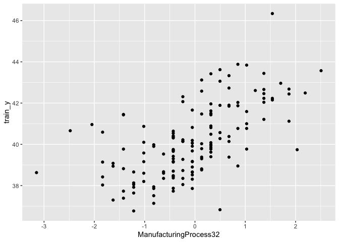

```r
ggplot(as.data.frame(train_X), aes(ManufacturingProcess32, train_y)) +
  geom_point()
```

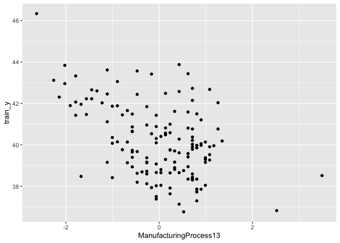

```r
ggplot(as.data.frame(train_X), aes(ManufacturingProcess13, train_y)) +
  geom_point()
```

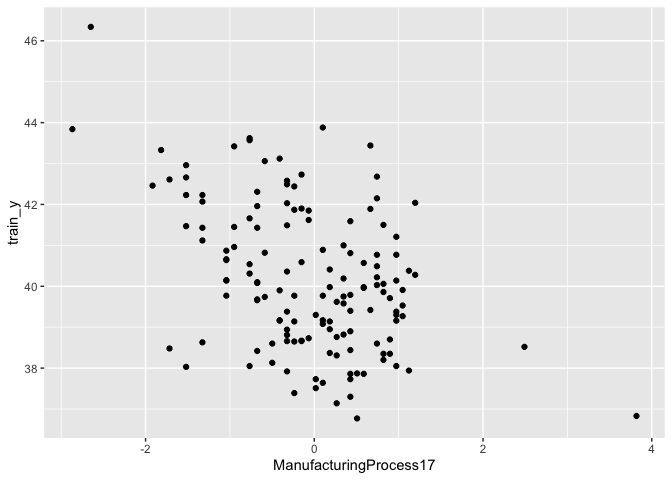

```r
ggplot(as.data.frame(train_X), aes(ManufacturingProcess17, train_y)) +
  geom_point()
```

Well, the top predictors look pretty linear. Probably why the linear model was better. Good that we checked other models (might as well to tree boosted in a few weeks!!), but so far a standard linear model looks like a good bet.